# TA5: Introduction to web scraping

## Expected outcomes

By the end of this TA, you should be able to explain:

- what a web page actually is — the HTML / DOM tree, CSS selectors, and how a browser turns one into the other
- the difference between a static page (where the HTML response already contains the data) and a dynamic page (where JavaScript renders the data after the page loads)
- the `rvest` workflow: `read_html()` → `html_elements()` → `html_text2()` / `html_table()`
- when you must reach for a real browser instead — `chromote` or `RSelenium`
- the legal and ethical rules that should bind every scraper you write: User-Agent, robots.txt, rate limiting, Terms of Service, copyright, and GDPR
- how to turn raw HTML into a small but useful dataset and run a basic text analysis on it

Download TA5 Code

The full source script is `code/06_ta5_webscraping.R`. Every result you see on this page is generated by that script and saved into `output/tables/`, `output/figures/`, or `output/text/`.

## The main empirical question

This TA is built around a single concrete question:

**What can we learn about the largest US banks by scraping public web data, and how do we do it safely, ethically, and reproducibly?**

The web is the largest and least-curated dataset humanity has ever assembled. A surprising fraction of recent finance papers — Adams & Mosk (2023) on letters to Congress, Akcigit, Baslandze & Lotti (2023) on political connections in patents, Akey, Heimer & Lewellen (2021) on politicised consumer credit, Babenko, Fedaseyeu & Zhang (2020) on CEO political donations — rely on data that exists only because someone scraped it. None of those papers had a paid Bloomberg-like data feed; they all sat down with HTML pages and parsed them.

For our example we scrape Wikipedia’s [List of largest banks in the United States](https://en.wikipedia.org/wiki/List_of_largest_banks_in_the_United_States), follow the links to each bank’s individual article, and assemble a small text corpus we can do real analysis on. Wikipedia is an honest teaching example because:

- it is **explicitly OK to scrape** under the CC-BY-SA licence (with attribution),
- it is **stable** — the wikitable structure and the URL scheme barely change from year to year,
- it lets us combine **structured** data (the table) with **unstructured** data (the article text), which is exactly the workflow most finance scraping projects end up using.

## Web scraping

A web page is just a tree of HTML tags. Your browser receives that tree, runs any JavaScript attached to it, and renders the result. A scraper does the first step (download the tree) and skips the second (rendering) — which is why static scraping works only when the data you want is already in the response.

### The `rvest` workflow

In R the canonical static-scraping pipeline is three function calls:

```r
page <- xml2::read_html("https://example.com/some-page")

table <- page |>
  rvest::html_elements("table.wikitable") |>
  rvest::html_table(fill = TRUE) |>
  purrr::pluck(1)

paragraphs <- page |>
  rvest::html_elements("div.mw-parser-output > p") |>
  rvest::html_text2()
```

Three things to internalise:

- **CSS selectors** are the language we use to point at HTML elements. `table.wikitable` means “every `<table>` whose class includes `wikitable`”. `div.mw-parser-output > p` means “every `<p>` that is an immediate child of `<div class='mw-parser-output'>`”. The browser developer tools give you these selectors for free — right-click any element and choose *Inspect*.
- `html_elements()` returns a **set** of nodes, `html_element()` returns a **single** node. They have the same name minus an `s` and the difference matters once you start nesting walks.
- `html_text2()` is almost always what you want for human-readable text. `html_text()` keeps every `\n` and `\t` exactly as they appear in the source, which produces ugly output 90% of the time.

### When `rvest` is enough — and when it is not

`rvest` is enough whenever the data you want is in the HTML response. You can check this in 30 seconds: open the page in the browser, view the page source (`Cmd-U` / `Ctrl-U`), and search the source for the value you can see on the page. If it is there, `rvest` will find it. If the search returns nothing, the page is rendered dynamically by JavaScript and you need a real browser, which is what `chromote` and `RSelenium` are for. We come back to this in the *When you need a real browser* section below.

## Legal and ethical considerations

Scraping is not technically illegal in most jurisdictions, but it can break a contract (the site’s Terms of Service), violate copyright, violate computer-misuse statutes if the target tries to block you and you keep going, or violate privacy law if the data is personal. The rules below are what a careful empirical researcher always follows.

### The seven rules of polite scraping

1. **Identify yourself.** Always send a meaningful `User-Agent` header. The script in this TA sends `Finance4-TA5-educational-scraper/1.0 (... contact e-mail ...)`. A site admin who sees that string can decide whether they care; an anonymous bot just gets blocked.
2. **Respect `robots.txt`.** Every well-behaved site publishes one at `/robots.txt`. Wikipedia’s, for instance, lists every directory that bots are not supposed to crawl. Read it and obey it.
3. **Throttle.** A single request per second is a safe default for small projects. The `httr2::req_throttle()` helper does this for you; the polite-scraping pattern in `code/00_utils.R` does it via `Sys.sleep(1)`.
4. **Cache everything.** Scrape once, analyse forever. The cached HTML is part of your dataset and must be archived alongside your code; otherwise your work is not reproducible.
5. **Honour the licence.** Wikipedia is CC-BY-SA: any derivative dataset must keep the attribution and share-alike requirement. SEC EDGAR is public-domain. Most newspapers are not — they ban scraping in their Terms of Service even when their content is public.
6. **Mind GDPR (and equivalent laws).** As soon as the data you scrape contains personal information about identifiable EU residents, you are processing personal data and you need a lawful basis under GDPR. *“It is on the public web”* is not a lawful basis on its own.
7. **Prefer APIs.** Wikipedia, GitHub, Twitter (X), the SEC, the Federal Reserve, and most major data sources offer APIs. If an API exists, the API is more stable, more polite, and usually faster. Scraping is the fallback, not the goal.

### Examples of where this matters

- The **hiQ vs LinkedIn** litigation in the US (2017–2022) settled the rough principle that scraping public data from a site you do not have an account with is not a Computer Fraud and Abuse Act violation, but the case explicitly did not address ToS or copyright.
- The **Ryanair vs PR Aviation** ruling in the EU (2015) confirmed that a site’s ToS can prohibit scraping even when the scraping itself is technically legal.
- **Adams & Mosk (2023)** scrape letters that constituents send to Congress members — public, government records, free of personal-data issues. That is the kind of source you *can* scrape safely. A press archive that ToS-prohibits scraping is not.

## When you need a real browser

Most financial dashboards (Yahoo Finance ticker pages, Bloomberg-like front-ends, fund factsheet viewers, real-time market depth charts) are JavaScript-rendered. The HTML you receive over HTTP is a near-empty shell, and the actual table you can see in the browser is built client-side after the page loads. `rvest` cannot see that content because `rvest` does not run JavaScript.

The two standard R answers are:

- **`chromote`** is a thin wrapper around headless Chrome via the DevTools protocol. It is the modern recommendation: no Java required, well maintained, and easy to install.
- **`RSelenium`** is the older, classic Selenium binding. More universal — there are Selenium drivers for every browser — but heavier, requires Java, and is best run inside a Docker container.

The pattern with `chromote` looks like this. We do not run it as part of the TA pipeline because it requires a Chromium install on the lab machine, but the snippet is shipped as `output/text/ta5_chromote_snippet.R` so you can reuse it in your own work.

```r
library(chromote)
b <- ChromoteSession$new()
b$Page$navigate("https://example.com/dashboard")
b$Page$loadEventFired()
rendered <- b$DOM$getDocument() |>
  purrr::pluck("root", "nodeId") |>
  (\(id) b$DOM$getOuterHTML(nodeId = id))() |>
  purrr::pluck("outerHTML")
b$close()
parsed <- xml2::read_html(rendered)
```

Once you have `parsed`, the rest of the pipeline (`html_elements`, `html_table`, …) is identical to the static case.

## Where this fits in finance research

Web scraping is rarely the contribution of a paper, but it is often the *enabling step* without which the paper could not have happened. A few examples directly from the syllabus reading list:

- **Adams & Mosk (2023)** — *Dear Congress Member*. Scrape letters from constituents to congress members and use NLP to detect mentions of financial regulation. The paper is identification + text analysis; the data only exists because someone wrote a careful scraper.
- **Akcigit, Baslandze & Lotti (2023)** — *Connecting to Power*. Combine patent data with political-connection records. The political-connection panel is hand-built from a mix of scraped and bulk-downloaded sources.
- **Babenko, Fedaseyeu & Zhang (2020)** — *Do CEOs Affect Employees’ Political Choices?* Match employee donor records (FEC) to firm rosters. The matching dictionary is built by scraping public profiles.
- **Akey, Heimer & Lewellen (2021)** — *Politicising Consumer Credit*. Build a panel of FOMC and political appointments by scraping the relevant agency websites.

Notice the pattern: the scrape produces a small, well-documented dataset that is then merged with a standard panel. The paper’s contribution is the merge and the identification — not the scrape — but without the scrape there is no paper.

## Time to code

```r
source("code/00_utils.R")
load_finance4_packages()

REFRESH_CACHE <- FALSE   # set to TRUE if you want a fresh scrape

ensure_dir("data/raw_wikipedia")
ensure_dir("data/raw_wikipedia/banks")
```

The full script is `code/06_ta5_webscraping.R`. The remainder of this section walks through every result the script produces, **in the same order it produces them**.

### Step 1: Robots.txt and the polite scraper

Before we scrape anything, we fetch and cache `/robots.txt`. The Wikipedia file is long, so we extract just the directives that matter — `User-agent`, `Disallow`, `Allow`, `Crawl-delay`. The full log is at `output/text/ta5_ethics_log.txt`.

```
TA5 polite-scraping log
Built on: 2026-05-06 12:05:23 CEST
User-Agent sent: Finance4-TA5-educational-scraper/1.0 (Bocconi PhD teaching assistant; alejandra.inzunza@phd.unibocconi.it)
Robots.txt cached at: data/raw_wikipedia/robots.txt
First robots.txt directives we matched:
User-agent: MJ12bot
Disallow: /
User-agent: Mediapartners-Google*
Disallow: /
User-agent: IsraBot
Disallow:
User-agent: Orthogaffe
```

Two things to notice:

- The header records the **exact User-Agent** we sent. This is good practice for reproducibility and accountability — anyone reading the log later knows who scraped what and how to contact us.
- Wikipedia’s `robots.txt` is permissive for normal crawlers but explicitly **blocks** several aggressive bots (`MJ12bot`, `WebCopier`, `WebStripper`, …). Reading the file yourself before you scrape is part of the contract.

### Step 2: Scrape the table of largest US banks

The page contains several `<table class="wikitable">` blocks. We extract them all with `rvest::html_table(fill = TRUE)`, keep the first one, and clean the column names. Because Wikipedia tables drift over time (column headings change wording, footnote markers leak in), we normalise headers and parse numeric values defensively.

Largest US banks by total assets (Wikipedia, scraped)

| Rank | Bank | Headquarters | Total assets (US$ bn) |
| --- | --- | --- | --- |
| 1 | JPMorgan Chase | New York City | 4424 |
| 2 | Bank of America | Charlotte, North Carolina | 3411 |
| 3 | Citigroup | New York City | 2657 |
| 4 | Wells Fargo | San Francisco, California | 2148 |
| 5 | Goldman Sachs | New York City | 1809 |
| 6 | Morgan Stanley | New York City | 1420 |
| 7 | U.S. Bancorp | Minneapolis, Minnesota | 692 |
| 8 | Capital One | Tysons, Virginia | 669 |
| 9 | PNC Financial Services | Pittsburgh, Pennsylvania | 573 |
| 10 | Truist Financial | Charlotte, North Carolina | 547 |
| 11 | TD Bank, N.A. | Cherry Hill, New Jersey[a] | 519 |
| 12 | Charles Schwab Corporation | Westlake, Texas | 490 |
| 13 | The Bank of New York Mellon | New York City | 472 |
| 14 | State Street Corporation | Boston, Massachusetts | 366 |
| 15 | American Express | New York City | 300 |

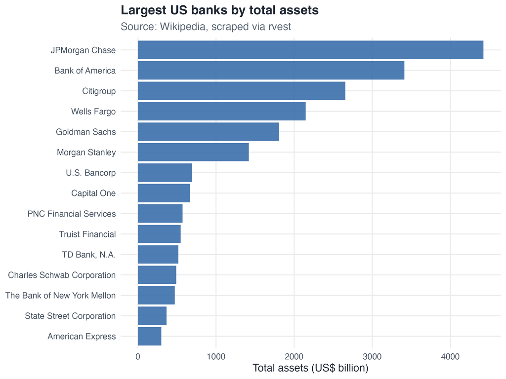

This is exactly the kind of dataset that is awkward to find pre-packaged but cheap to scrape: 15 rows, four columns, no JavaScript, no login. The total assets in US-dollar billions are the same numbers you would pay $40 for on a “list of largest banks” PDF aggregator.

### Step 3: Follow links to each bank’s article

Each row in the wikitable contains a `<a href="…">` link to the bank’s individual Wikipedia article. We walk the `<tr>` elements of the same table, extract the first `<a>` from the bank-name cell, and build absolute URLs. We then loop over the URLs with `purrr::map2()`, calling `fetch_or_cache()` on each one — this is where the polite-scraping helpers from `code/00_utils.R` earn their keep.

Bank URLs scraped from the wikitable, used as the entry points for the corpus.

| Rank | Bank | Headquarters | URL |
| --- | --- | --- | --- |
| 1 | JPMorgan Chase | New York City | JPMorgan_Chase |
| 2 | Bank of America | Charlotte, North Carolina | Bank_of_America |
| 3 | Citigroup | New York City | Citigroup |
| 4 | Wells Fargo | San Francisco, California | Wells_Fargo |
| 5 | Goldman Sachs | New York City | Goldman_Sachs |
| 6 | Morgan Stanley | New York City | Morgan_Stanley |
| 7 | U.S. Bancorp | Minneapolis, Minnesota | U.S._Bancorp |
| 8 | Capital One | Tysons, Virginia | Capital_One |
| 9 | PNC Financial Services | Pittsburgh, Pennsylvania | PNC_Financial_Services |
| 10 | Truist Financial | Charlotte, North Carolina | Truist |
| 11 | TD Bank, N.A. | Cherry Hill, New Jersey[a] | TD_Bank_(United_States) |
| 12 | Charles Schwab Corporation | Westlake, Texas | Charles_Schwab_Corporation |
| 13 | The Bank of New York Mellon | New York City | BNY |
| 14 | State Street Corporation | Boston, Massachusetts | State_Street_Corporation |
| 15 | American Express | New York City | American_Express |

Once the article HTML is in hand, we extract the first three substantial paragraphs of the article body — that is, the lead text. We deliberately drop very short paragraphs (less than 80 characters) to avoid section headers and stub fragments. The result is a small, coherent corpus.

| Rank | Bank | Excerpt |
| --- | --- | --- |
| 1 | JPMorgan Chase | JPMorgan Chase & Co. (stylized as JPMorganChase) is an American multinational banking institution headquartered in New York City and incorporated in Delaware. It is the largest bank in the United Stat… |
| 2 | Bank of America | The Bank of America Corporation (Bank of America; often abbreviated BAC or BofA) is an American multinational investment bank and financial services holding company headquartered at the Bank of Americ… |
| 3 | Citigroup | Citigroup Inc. or Citi (stylized as citi) is an American multinational investment bank and financial services company based in New York City. The company was formed in 1998 by the merger of Citicorp, … |
| 4 | Wells Fargo | Wells Fargo & Company is an American multinational financial services company.[5][8] The company operates in 35 countries and serves more than 70 million customers worldwide.[5] It is a systemically i… |
| 5 | Goldman Sachs | The Goldman Sachs Group, Inc. (/sæks/ SAKS) is an American multinational investment bank and financial services company. Founded in 1869, Goldman Sachs is headquartered in the Battery Park City neighb… |
| 6 | Morgan Stanley | Morgan Stanley[4] is an American multinational investment bank and financial services company headquartered at 1585 Broadway in Midtown Manhattan, New York City. With offices in 42 countries and more … |
| 7 | U.S. Bancorp | U.S. Bancorp (stylized as us bancorp) is an American multinational banking institution headquartered in Minneapolis, Minnesota and incorporated in Delaware. It is the 5th-largest bank in the United St… |
| 8 | Capital One | Capital One Financial Corporation is an American bank holding company headquartered in Tysons, Virginia, with operations in the United States, Canada, and the United Kingdom.[1] One of the largest ban… |
| 9 | PNC Financial Services | The PNC Financial Services Group, Inc. is an American bank holding company and financial services corporation based in Pittsburgh, Pennsylvania. Its banking subsidiary, PNC Bank, operates in 27 states… |
| 10 | Truist Financial | Truist Financial Corporation (/ˈtruːɪst/[6]) is an American bank holding company headquartered in Charlotte, North Carolina.[7] The company was formed in December 2019 as the result of the merger of B… |
| 11 | TD Bank, N.A. | TD Bank, N.A. (previously TD Banknorth) is an American national bank and the United States subsidiary of the Canadian multinational TD Bank Group. It operates primarily across the East Coast, in 15 U.… |
| 12 | Charles Schwab Corporation | The Charles Schwab Corporation[1] is an American multinational financial services company. It offers banking, commercial banking, investing, and related services including consulting, and wealth manag… |
| 13 | The Bank of New York Mellon | The Bank of New York Mellon Corporation, commonly known as BNY or by its prior brand name BNY Mellon, is an American international financial services company headquartered in New York City with major … |
| 14 | State Street Corporation | State Street Corporation is an American multinational[2]financial services and bank holding company headquartered at One Congress Street in Boston. It is the second-oldest continuously operating U.S. … |
| 15 | American Express | American Express Company (Amex) is an American bank holding company and multinational financial services corporation that specializes in payment cards. It is headquartered at 200 Vesey Street, also kn… |

Workflow rule. Each individual article is fetched at most once: the very first run downloads it, every subsequent run reads from `data/raw_wikipedia/banks/<slug>.html`. **The cache is part of the dataset**, and a serious project commits the cached HTML to the repository (or to a versioned data store) alongside the code.

### Step 4: When static scraping is not enough

Stop-and-think. The script writes out a small `chromote` snippet to `output/text/ta5_chromote_snippet.R` that you can lift into your own work later:

```r
# Pseudocode: scraping a JavaScript-rendered page with chromote
library(chromote)
b <- ChromoteSession$new()
b$Page$navigate("https://example.com/dashboard")
b$Page$loadEventFired()
rendered <- b$DOM$getDocument() |>
  purrr::pluck("root", "nodeId") |>
  (\(id) b$DOM$getOuterHTML(nodeId = id))() |>
  purrr::pluck("outerHTML")
b$close()
parsed <- xml2::read_html(rendered)
```

The point of this snippet is not the lines of code, it is the **mental flowchart**:

1. Open the target page in a normal browser.
2. View the page source. Search for the value you can see on the page.
3. If the value is in the source, `rvest` is enough. Stop.
4. If the value is not in the source, the page is JavaScript-rendered. Use `chromote`.

We do not run `chromote` in the TA5 pipeline because installing a Chromium binary on every student’s laptop is a different kind of fight. The snippet is a reference, not a hidden dependency.

### Step 5: Tokenisation and term frequencies

Now we turn the `lead_text` column into one row per word with `tidytext::unnest_tokens()`, drop standard English stopwords, and remove a small custom list of words that would dominate a corpus made of bank Wikipedia pages (`bank`, `banks`, `company`, `incorporated`, `headquartered`, `american`, …). Customising stopwords is a normal step in finance text analysis: the standard lists are tuned for general English, not for sector-specific corpora.

Size of the cleaned corpus.

| # banks | # tokens | # unique words |
| --- | --- | --- |
| 15 | 1750 | 752 |

The most frequent terms across the whole corpus give a quick sanity check on the scrape: if `financial`, `services`, `investment`, `management`, … dominate, the corpus is doing what we expect. If the top words were `references`, `external`, `links`, that would tell us we accidentally scraped the bibliography sections.

Top 25 words across the scraped Wikipedia corpus.

| Word | Frequency |
| --- | --- |
| financial | 42 |
| services | 37 |
| investment | 24 |
| management | 24 |
| assets | 18 |
| america | 16 |
| ranked | 15 |
| morgan | 14 |
| card | 13 |
| founded | 13 |
| market | 13 |
| wealth | 12 |
| amex | 11 |
| asset | 11 |
| branch | 11 |
| branches | 11 |
| business | 11 |
| commercial | 11 |
| global | 11 |
| multinational | 11 |
| bny | 10 |
| chase | 10 |
| considered | 10 |
| credit | 10 |
| fortune | 10 |

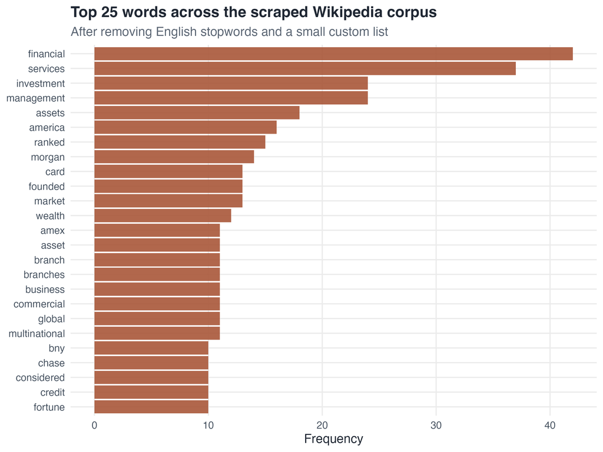

We also save the top three words **per bank** to `output/tables/ta5_top_terms_per_bank.csv`. This is a quick eyeball check that each bank’s article is parsed correctly: if all 15 banks share exactly the same top words, the lead-paragraph extraction has gone wrong somewhere.

### Step 6: A simple finance tone score

A standard next step in finance text analysis is to score a document with a financial sentiment dictionary — Loughran & McDonald (2011) is the canonical choice. We use a deliberately small, transparent stand-in dictionary defined in `code/00_utils.R` (15 positive words, 23 negative ones) so the mechanics are visible at a glance. The score per bank is

$$\text{tone}_b \;=\; \frac{(\text{positive matches})_b - (\text{negative matches})_b}{(\text{total tokens})_b}.$$

Finance tone score per bank from scraped Wikipedia text.

| Rank | Bank | Total tokens | Positive | Negative | Tone |
| --- | --- | --- | --- | --- | --- |
| 1 | JPMorgan Chase | 142 | 3 | 1 | 0.0141 |
| 2 | Bank of America | 182 | 7 | 1 | 0.0330 |
| 3 | Citigroup | 75 | 3 | 0 | 0.0400 |
| 4 | Wells Fargo | 100 | 1 | 1 | 0.0000 |
| 5 | Goldman Sachs | 154 | 3 | 0 | 0.0195 |
| 6 | Morgan Stanley | 106 | 3 | 0 | 0.0283 |
| 7 | U.S. Bancorp | 106 | 2 | 0 | 0.0189 |
| 8 | Capital One | 99 | 0 | 1 | -0.0101 |
| 9 | PNC Financial Services | 102 | 0 | 0 | 0.0000 |
| 10 | Truist Financial | 113 | 1 | 1 | 0.0000 |
| 11 | TD Bank, N.A. | 114 | 0 | 3 | -0.0263 |
| 12 | Charles Schwab Corporation | 137 | 4 | 0 | 0.0292 |
| 13 | The Bank of New York Mellon | 128 | 0 | 0 | 0.0000 |
| 14 | State Street Corporation | 70 | 0 | 0 | 0.0000 |
| 15 | American Express | 122 | 0 | 0 | 0.0000 |

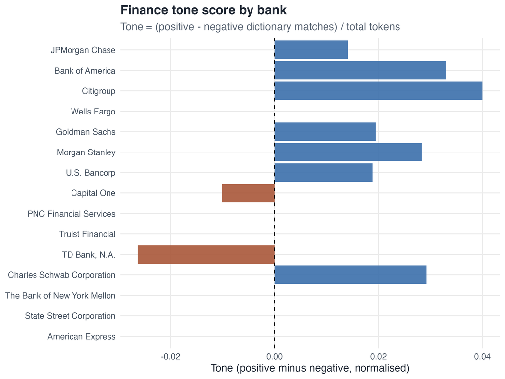

### Step 7: LaTeX exports

The script also exports two LaTeX tables — the bank list and the tone scores — to `output/tables/ta5_top_banks.tex` and `output/tables/ta5_tone_scores.tex`, ready to drop into a draft with `\input{...}`. Together with the cached HTML in `data/raw_wikipedia/`, this is the full reproducible bundle you would attach to a referee report.

### Question for you

> Suppose you want to extend this exercise to the **largest 100 US banks** rather than just the top 15.
> 1. Which step (or steps) of the script would you change, and why?
> 2. What would you do to keep the scrape polite — both legally and operationally — at that scale?
> 3. If the lead paragraphs of the smaller banks turn out to be only one or two sentences, which step of the pipeline would you redesign so that the corpus stays comparable across banks?

## What to take away

A few things to internalise from this TA:

- A scraper is a **research instrument** and should be designed like one: identifiable, throttled, cached, documented, and obedient to the source’s licence and terms.
- Static scraping with `rvest` covers the vast majority of finance use cases. Reach for `chromote` (or `RSelenium`) only when the data is genuinely JavaScript-rendered — and check by viewing the page source first.
- The **cache is the dataset.** If your colleague cannot reproduce your tables six months from now without the cached HTML, you have not really done reproducible research.
- Once you have the corpus, the rest is small data: `tidytext` for tokenisation, a transparent dictionary for tone, plain dplyr for everything else. The complicated step is getting the data, not analysing it.

A few questions you should be able to answer:

- Why is sending a real `User-Agent` the cheapest favour you can do for both your project and the server you are scraping?
- What is the difference between `html_element()` and `html_elements()`, and when does it matter?
- Why would you cache scraped HTML on disk even on a fast network connection?
- What would it take, operationally and legally, to extend this scrape to a non-Wikipedia source — say, a national newspaper?
- Why is the Loughran-McDonald financial sentiment dictionary preferable to a general-purpose dictionary like AFINN or Bing for finance text?

For the formal references behind everything above:

- Loughran, T., and B. McDonald (2011), “When is a Liability not a Liability? Textual Analysis, Dictionaries, and 10-Ks”, *Journal of Finance* 66(1), 35–65.
- Adams, R., and T. Mosk (2023), “Dear Congress Member: Letters to Congress and the Shaping of (Financial) Legislation”, working paper, University of Oxford.
- Akcigit, U., S. Baslandze, and F. Lotti (2023), “Connecting to Power: Political Connections, Innovation, and Firm Dynamics”, *Econometrica* 91(2), 529–564.
- Babenko, I., V. Fedaseyeu, and S. Zhang (2020), “Do CEOs Affect Employees’ Political Choices?”, *Review of Financial Studies* 33(4), 1781–1817.
- Akey, P., R. Z. Heimer, and S. Lewellen (2021), “Politicizing Consumer Credit”, *Journal of Financial Economics* 139(2), 627–655.